# Computational Essay

Author

Marzhan Nuraly

## Introduction

The number of tourists and overseas employees in the Bay area increasing every year. Due to population rise, planning of city infrastructure is becoming popular in California State.

In this computational essay, we will summarize and visualize data for tourist and citizen usage, including the AirBnb dataset, and data classification by socio-economic variables from Census API. Moreover, regionalisation city of San Francisco by land usage and economic purpose.

## Airbnb in the BAY AREA at Neighbourhood Level

### Data pre-processing

The Airbnb dataset for 3 cities, San Francisco, San Mateo, Oakland. The analysis of the dataset gives opportunities to make a summary of tourism and economic analysis for the region. The data pre-processing method for outlier identification was applied.

```r
listings_SanFran <- read.csv("data/SanFrancisco/listings.csv")

# REMOVE OUTLIERS

listings_SanFran <- listings_SanFran %>%
  mutate(z_score = (number_of_reviews - mean(number_of_reviews)) / sd(number_of_reviews))

threshold <- 3

filtered_data <- listings_SanFran %>%
  filter(abs(z_score) <= threshold) %>%
  select(-z_score)

write.csv(filtered_data, "data/nooutliers/listings_nooutliers_fr.csv", row.names = FALSE)


listings_SanMateo <- read.csv("data/SanMateo/listings.csv")

listings_SanMateo <- listings_SanMateo %>%
  mutate(z_score = (number_of_reviews - mean(number_of_reviews)) / sd(number_of_reviews))

filtered_data_sn <- listings_SanMateo %>%
  filter(abs(z_score) <= threshold) %>%
  select(-z_score)


write.csv(filtered_data_sn, "data/nooutliers/listings_nooutliers_mt.csv", row.names = FALSE)


listings_Oak <- read.csv("data/Oakland/listings.csv")

listings_Oak <- listings_Oak %>%
  mutate(z_score = (number_of_reviews - mean(number_of_reviews)) / sd(number_of_reviews))

filtered_data_oa <- listings_Oak %>%
  filter(abs(z_score) <= threshold) %>%
  select(-z_score)

write.csv(filtered_data_oa, "data/nooutliers/listings_nooutliers_oa.csv", row.names = FALSE)
```

```r
setwd("data/nooutliers")

csv_files <- list.files(pattern = ".csv")

df_list <- list()

for (file in csv_files) {
  df <- read.csv(file, header = TRUE)
  df_list <- append(df_list, list(df))
}

combined_df <- do.call(rbind, df_list)

write.csv(combined_df, "listings_Bay_Area.csv", row.names = FALSE)
```

The data of listings joined for one .csv file by the function rbind. rbind [(CN, 2022)](https://www.digitalocean.com/community/tutorials/rbind-function-r) row binding, joining multiple rows into single frame.

```r
# Read combined csv file with Bay Area listings
listings_Bay_Area <- read.csv("data/nooutliers/listings_Bay_Area.csv")
```

The second data used for classification is Bay Area Zip codes in the format ShapeFile from Berkeley library.

```r
shape_BayArea <- read_sf("data/data_1/bayarea_zipcodes.shp")

shape_BayArea <- st_make_valid(shape_BayArea)

bay_zip_sorted <- shape_BayArea[shape_BayArea$PO_NAME %in% c("SAN FRANCISCO", "SOUTH SAN FRANCISCO", "OAKLAND", "SAN MATEO", "DALY CITY", "PACIFICA", "MOSS BEACH", "BURLINGAME", "HALF MOON BAY", "SAN BRUNO", "BRISBANE", "MILLBRAE", "SAN CARLOS", "PALO ALTO", "REDWOOD CITY"),]

bay_zip_sorted <- st_make_valid(bay_zip_sorted)
```

### Spatial Join

The points were created from the longitude and latitude of listings. Then we set EPSG:4326 coordinate system because it uses coordinates to specify locations on the surface. In addition, WGS84 has a similar projected system, but EPSG:4326 is the standard coordinate system used in GIS and good for use in large areas Moreover this projection system is based on WGS84 and includes projection properties of this CRS (Coordinate Reference System). As we get points, we should join points with polygons of zip codes in the Bay Area. st_join ([Wickham 2023](https://cran.r-project.org/web/packages/sfnetworks/vignettes/sfn03_join_filter.html)) joining intersections by spatial relations. To get data without losing spatial objects should have similar Coordinate Reference Systems.

```r
airbnb_sf <- listings_Bay_Area %>%
  st_as_sf(coords = c("longitude", "latitude")) %>%
  st_set_crs(4326)

airbnb_sf <- st_transform(airbnb_sf, crs = st_crs(bay_zip_sorted))
```

```r
# SPATIAL JOIN
listing_Bay_area_join <- st_join(bay_zip_sorted, airbnb_sf)
```

```r
summary_data_1 <- listing_Bay_area_join %>%
  group_by(ZIP) %>%
  summarize(listing_count = n(),
         average_price = mean(price))
```

### Data classification

Choropleth maps are used for classification, this map is visually effective for large-scale values, and easy-to-interpret block shading makes it easier to understand variations. Data classification was done in quantile intervals, which arranges groups with the same quantity, and comparing them to an equal classifier gives balanced results for grouping data, which avoids having classes with outlier results and prevents null value. In quantile intervals, the number of classes is selected as 6 because distortion is minimised with a higher number of classes.

```r
# Number of listings classification
equal_cl <- classIntervals(summary_data_1$listing_count, n = 6, style = "quantile")
summary_data_1$equal_cl <- cut(summary_data_1$listing_count, equal_cl$brks)
```

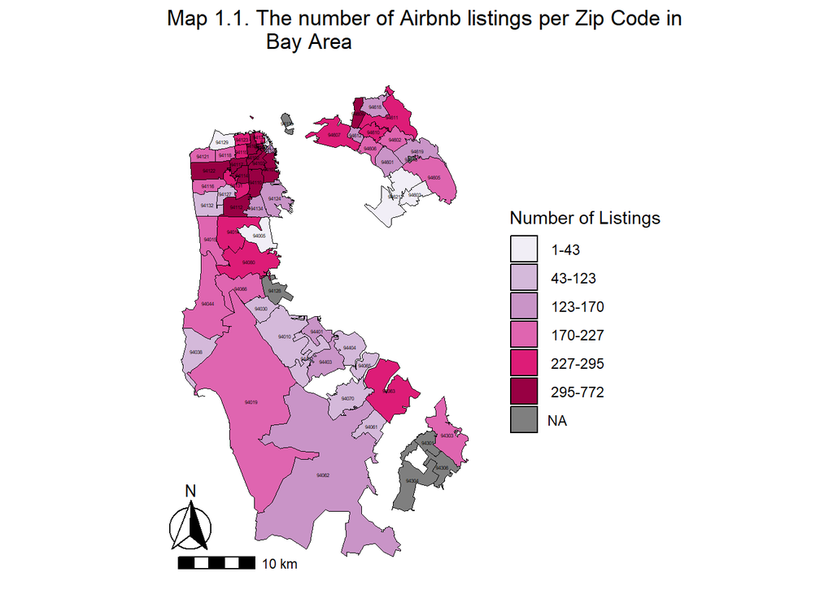

```r
num_bins <- 6
cmap <- brewer.pal(num_bins, "PuRd")

ggplot() +
  geom_sf(data = bay_zip_sorted, fill = "white", color = "black") +
  geom_sf(data = summary_data_1, aes(fill = equal_cl), color = "black") +
  scale_fill_manual(
    values = cmap,
    name = "Number of Listings",
    labels = gsub("[,]", "-", paste0(gsub("[\\[\\]()]", " ", levels(summary_data_1$equal_cl), perl = TRUE)))
  ) +
  geom_sf_text(data = summary_data_1,
               aes(label = ZIP),
               fun.geometry = sf::st_centroid, size=1) +
  labs(title = "Map 1.1. The number of Airbnb listings per Zip Code in
                Bay Area") +
  theme_minimal()+
  annotation_scale(location = "bl", width_hint = 0.4) +
  annotation_north_arrow(location = "bl", which_north = "true",
        pad_x = unit(-0.1, "in"), pad_y = unit(0.2, "in"),
        style = north_arrow_fancy_orienteering) +
  theme(
    panel.grid.major = element_blank(),
    panel.grid.minor = element_blank(),
    axis.text = element_blank(),
    axis.title = element_blank(),
    axis.ticks = element_blank()
  )
```

```r
# Average price of listings in ZIP level classification
jenks_cl <- classIntervals(summary_data_1$average_price, n = 5, style = "jenks")
summary_data_1$jenks_cl <- cut(summary_data_1$average_price, jenks_cl$brks)
```

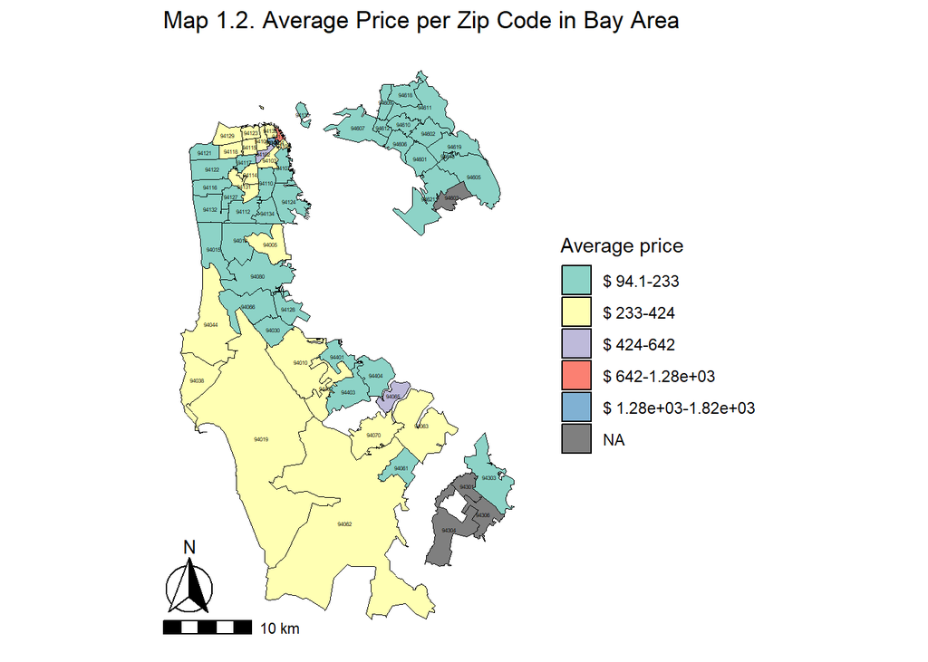

```r
cmap_2 <- brewer.pal(num_bins, "Set3")

ggplot() +
  geom_sf(data = bay_zip_sorted, fill = "white", color = "black") +
  geom_sf(data = summary_data_1, aes(fill = jenks_cl), color = "black") +
  scale_fill_manual(
    values = cmap_2,
    name = "Average price",
    labels = paste0("$", gsub("[,]", "-", paste0(gsub("[\\[\\]()]", " ", levels(summary_data_1$jenks_cl), perl = TRUE))))
  ) +
  geom_sf_text(data = summary_data_1,
               aes(label = ZIP),
               fun.geometry = sf::st_centroid, size=1, color="black") +
  labs(title = "Map 1.2. Average Price per Zip Code in Bay Area") +
  theme_minimal() +
  annotation_scale(location = "bl", width_hint = 0.4,
                   pad_x = unit(0.0, "in")) +
  annotation_north_arrow(location = "bl", which_north = "true",
        pad_x = unit(-0.1, "in"), pad_y = unit(0.2, "in"),
        style = north_arrow_fancy_orienteering) +
  theme(
    panel.grid.major = element_blank(),
    panel.grid.minor = element_blank(),
    axis.text = element_blank(),
    axis.title = element_blank(),
    axis.ticks = element_blank()
  )
```

The choropleth map for the average prices of AirBnb listings to ZIP is classified by Natural break intervals. This style is the most optimal class range to classify data “naturally”, where the class range is identified by similar characteristics and forms natural groups. After classification, the highest cost between 1280 dollars (1.28e+03) and 1820 dollars (1.82e+03) is in the ZIP “94192”, San Francisco. The lowest prices are in west, east and south San Francisco and Oakland. In the San Mateo country, most ZIP areas have lower average costs from 233 to 424 dollars for Airbnb.

After visualizing Bay Area Airbnb listings, San Francisco is a more popular city compared to San Mateo and Oakland. The dataset includes information about the number of reviews, descriptions, availability and room types. The potential bias of the data is that it doesn’t include more information about reviews. The reviews and their ratings are necessary to make clustering of rents that will make an impact on rent representation.

## Socio-economic variables from the ACS data

In this section, the Bay Area is analysed with socio-economic variables from the ACS data. The purpose of this analysis is to explore the spatial distribution of variables and visualize the proportion of neighbourhoods.

```r
# The variables of median household income and the number of employers of all races working in the rental sphere.

# MEDIAN HOUSEHOLD INCOME = B19013_001
# INDUSTRY CLASS OF WORKERS (RENTAL) = C24070_065E

bay_unit <- get_acs(
  state = "CA",
  county = c(sanfran = "San Francisco", sanmateo = "San Mateo", contracosta = "Contra Costa", alameda= "Alameda"),
  geography = "tract",
  variables = c("B19013_001", "C24070_065E"),
  geometry = TRUE,
  summary_var = "C24020_001",
  year = 2020,
  output = "wide"
)

#The main 2 variables are "B19013_001" and "C24070_065E". The data in sf form and the column names are changed for a fast understanding of their purpose.
```

```r
bay_unit <- bay_unit %>%
  select(GEOID, medianIncome = B19013_001E, emp_pop = C24070_065E, summary_est) %>%
  filter(complete.cases(medianIncome))
```

According to ([Stevens 2015](https://www.joshuastevens.net/cartography/make-a-bivariate-choropleth-map/)), the data must be pre-processed if it’s a number unit, then the percentage must be calculated.

```r
bay_unit <- bay_unit %>% mutate(percent = 100 * (emp_pop / summary_est))%>% select(GEOID, medianIncome, percent)
```

Bivariate choropleth maps giving visualization to the spatial relationship between quantitative variables ([Christopher Prener, 2022](https://cran.r-project.org/web/packages/biscale/vignettes/biscale.html)). The data was classified with the Natural Breaks (Jenks) style that creates groups with similar values and maximizes the differences between groups.

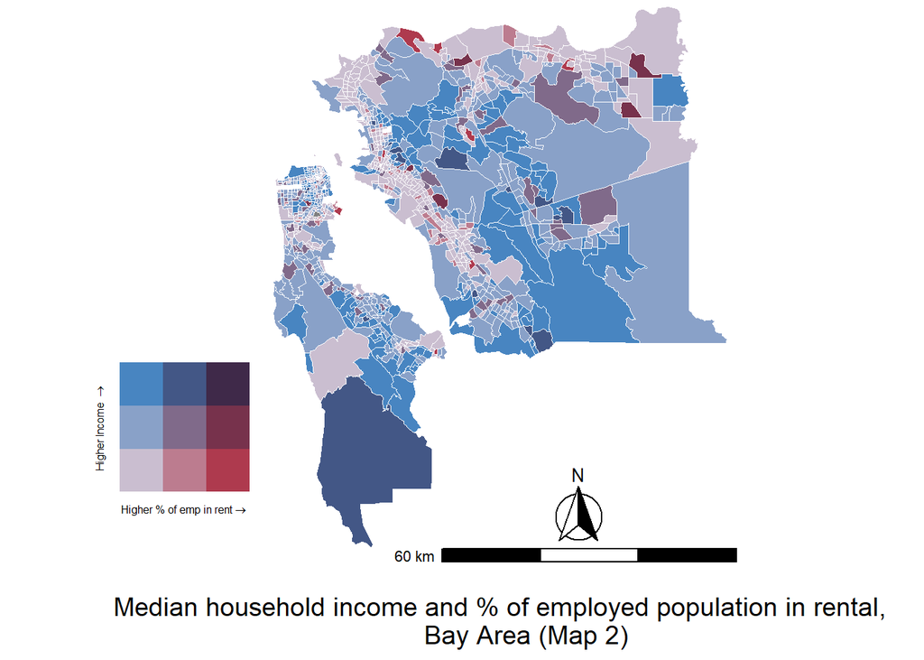

```r
bi_dd <- bi_class(bay_unit, x = percent, y = medianIncome, style = "jenks", dim = 3)

map_2 <- ggplot() +
  geom_sf(data = bi_dd, mapping = aes(fill = bi_class), color = "white", size = 0.5, show.legend = FALSE) +
  bi_scale_fill(pal = "DkViolet", dim = 3) +
  bi_theme() +
  annotation_scale(location = "br", width_hint = 0.6) +
  annotation_north_arrow(location = "br", which_north = "true",
        pad_x = unit(1, "in"), pad_y = unit(0.2, "in"),
        style = north_arrow_fancy_orienteering) +
  theme(
    plot.title = element_text(size = 9, angle = 90, vjust = 1, hjust = 0)) +
  labs(caption="Median household income and % of employed population in rental,
       Bay Area (Map 2)")


legend_1 <- bi_legend(pal = "DkViolet",
                    dim = 3,
                    xlab = "Higher % of emp in rent",
                    ylab = "Higher Income ",
                    size = 6)

finalPlot <- ggdraw() +
  draw_plot(map_2, 0, 0, 1.07, 1.07) +
  draw_plot(legend_1, 0.04, 0.2, 0.3, 0.3)

finalPlot
```

By the classification with two dimensions, the map visualize: grey areas - low median household income and low percentage of employees in the rental. Blue areas - high household income and a low percentage of rental workers. Violet areas - high household income and high percentage of employees in rental. Red areas are low-income and high percentage of people working on rental. In the city of San Francisco, most of the areas have high incomes and a low percentage of rental workers. This classification means that in that area more homeownership can be characterised as residential neighbourhoods.

The characteristics for typology in economics, those areas described as well-being neighbourhoods. Also, this class identify the low dependence of the rental income. By analysing two data, we can indicate equal residents and rental business neighbourhoods and identify that there is a larger rental industry presence. As a result, Airbnb can be clustered as affordable and economically stable. The San Mateo country mostly has residential neighbourhoods and well-being neighbourhoods. In contrast, similar neighbourhoods and clusters can be used in Oakland.

## Combining Data sets

In this part, datasets are combined to get more information about the relationship between the data.

Firstly, the frame of socio-economic variables is transferred to the CRS system “EPSG”,2227.

```r
summary_data_1 <- subset(summary_data_1, select = -equal_cl)

airbnb_soc_all <- st_transform(bay_unit, crs = st_crs(summary_data_1))
```

```r
airbnb_soc_all_joined <- st_join(airbnb_soc_all, summary_data_1)
airbnb_soc_all_joined <- na.omit(airbnb_soc_all_joined)
```

```r
airbnb_price_inc <- airbnb_soc_all_joined %>%
  group_by(ZIP) %>%
  mutate(medianIncome, ln_price = log(average_price))
```

```r
airbnb_price_inc <- subset(airbnb_price_inc, ln_price > 0)
```

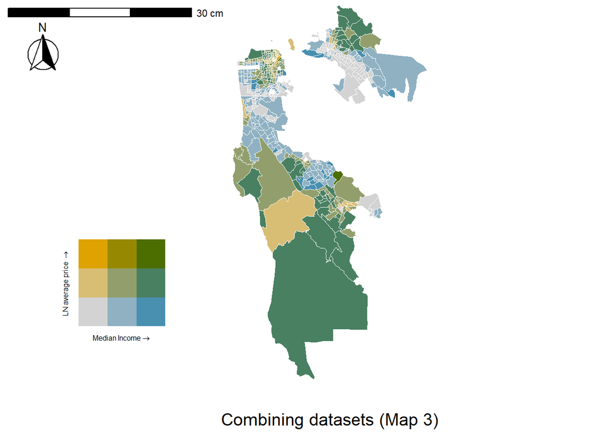

```r
bi_dd_gh <- bi_class(airbnb_price_inc, x = medianIncome , y = ln_price, style = "jenks", dim = 3)

map_3 <- ggplot() +
  geom_sf(data = bi_dd_gh, mapping = aes(fill = bi_class), color = "white", size = 0.5, show.legend = FALSE) +
  bi_scale_fill(pal = "BlueGold", dim = 3) +
  bi_theme() +
  theme(
    plot.title = element_text(size = 10),
    legend.position="bottom") +
  labs(caption="Combining datasets (Map 3)")


legend_2 <- bi_legend(pal = "BlueGold",
                    dim = 3,
                    xlab = "Median Income",
                    ylab = "LN average price ",
                    size = 6)

fnPl <- ggdraw() +
  draw_plot(map_3, 0, 0, 1.07, 1.07) +
  draw_plot(legend_2, 0.04, 0.2, 0.3, 0.3) +
  annotation_north_arrow(location = "tl",
        pad_x = unit(0.5, "cm"), pad_y = unit(0.7, "cm"),
        style = north_arrow_fancy_orienteering) +
  annotation_scale(location = "tl", width_hint = 0.3)

fnPl
```

The relationship between Airbnb listings and socio-economic variables, the main income of the north side of San Francisco depends on the rental. Summarizing this data, the north and northeast of San Francisco are in the high rental industry neighbourhood. San Mateo and Oakland are both in the high rental industry neighbourhood and well-being neighbourhood or homeownership neighbourhood.

## Autocorrelation

Spatial autocorrelation stands for similarity of values of observation and similarity in locations. If adjacent data observation has similar data, then it’s positive autocorrelation, while if adjacent values have very different values it’s negative autocorrelation ([Haining, 2001](https://www.sciencedirect.com/science/article/abs/pii/B0080430767025110?via%3Dihub)).

```r
nb_q <- poly2nb(airbnb_price_inc, queen = TRUE)
w_queen_std <- nb2listw(nb_q, style = "W", zero.policy = TRUE)
```

```r
#STANDARDISING MEDIAN HOUSEHOLD INCOME
airbnb_price_inc$medianIncome_sd <- (airbnb_price_inc$medianIncome - mean(airbnb_price_inc$medianIncome))/sd(airbnb_price_inc$medianIncome)
```

Global Moran’s I was applied to check spatial autocorrelation’s existence using standardised data.

```r
airbnb_price_inc$lg_price <- lag.listw(w_queen_std, airbnb_price_inc$medianIncome_sd)
```

```r
# p-value < $\frac{1}{1 + N}$, where $N$ is the number of simulations.

MC<- moran.mc(airbnb_price_inc$medianIncome_sd, w_queen_std, nsim = 999)
MC
```

```
    Monte-Carlo simulation of Moran I

data:  airbnb_price_inc$medianIncome_sd
weights: w_queen_std
number of simulations + 1: 1000

statistic = 0.60368, observed rank = 1000, p-value = 0.001
alternative hypothesis: greater
```

The statistics of Moran’s I is calculated to test the theory that “the median household income values is classified randomly using randomness”. The Monte-Carlo testing approach is used with 999 simulation numbers. p-value = 0.001 analysed that data is strongly clustered (Gimond, 2019).

```r
lisa_perm <- localmoran_perm(airbnb_price_inc$medianIncome, w_queen_std, nsim=1000, alternative="two.sided")

quadrants <- hotspot(lisa_perm, Prname="Pr(z != E(Ii)) Sim", cutoff=0.1)

airbnb_price_inc$quadrant <- as.character(quadrants)  %>% replace_na("Non-mean")
```

To identify local clusters and local outliers Local Moran I applied. The hotspot() function is used to compute hot spot or outlier cutoff based on the normal distribution and p-value ([Darrouzet-Nardi, 2018](https://cran.r-project.org/web/packages/hotspots/hotspots.pdf)).

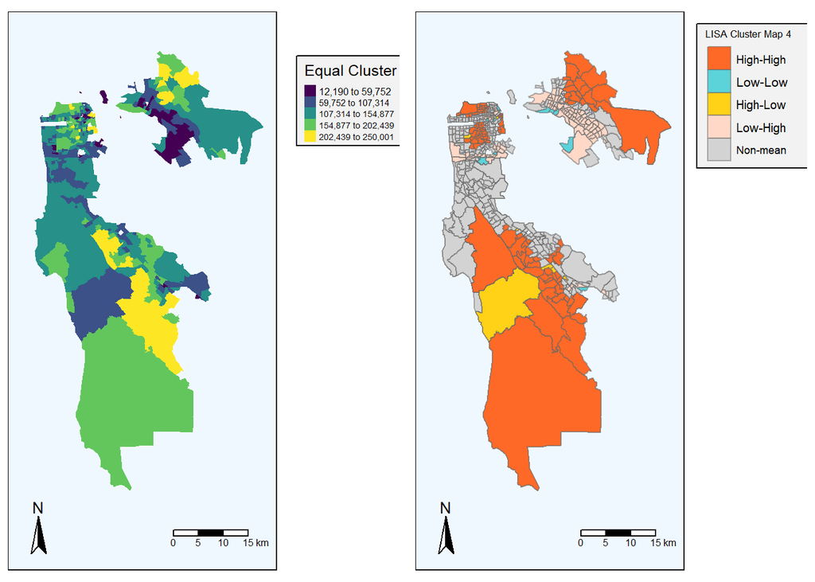

```r
cluster_plot <- tm_shape(airbnb_price_inc) +
  tm_fill(col = "medianIncome", palette = viridisLite::viridis(6),
              style = "equal", title="Equal Cluster") +
  labs(title = "Median Income cluster")+
  tm_compass(position = c(0.01, 0.03)) +
  tm_scale_bar(position = c(0.6, 0.03)) +
  tm_legend(bg.color="grey95", frame=TRUE) +
  tm_layout(legend.outside = TRUE, legend.text.size = 0.5, inner.margins = c(0.1, 0.1, 0.02, 0.05), legend.position = c(0.16,0.76), legend.width=0.5, bg.color="aliceblue")

lisa_plot <- tm_shape(airbnb_price_inc) + tm_fill(col = "quadrant", title = "",
breaks = c(1, 2, 3, 4, 5, 6),
palette =  c("#FF6927", "#5CD2D9", "#FFD117", "#FFD8C7", "lightgrey"),
labels = c("High-High", "Low-Low", "High-Low",
           "Low-High", "Non-mean")) +
tm_legend(text.size = 1)  + tm_borders(alpha = 0.5) +
tm_compass(position = c(0.01, 0.03)) +
tm_scale_bar(position = c(0.6, 0.03)) +
tm_layout(title = "LISA Cluster Map 4")  +
tm_legend(bg.color="grey95", frame=TRUE) +
tm_layout(legend.outside = TRUE, inner.margins = c(0.1, 0.1, 0.02, 0.05), bg.color="aliceblue")

tmap_arrange(cluster_plot, lisa_plot, sync = TRUE, ncol = 2)
```

On the left side is a choropleth map that visualises an equally clustered Map of the Bay Area with median income values, the map on the right is LISA’s result for median household incomes. In the map on the right, orange zones indicate areas with high median income values and high-valued neighbours, while blue indicates low values. According to maps, San Mateo country leading with high medium incomes. The north and central areas of San Francisco also have high-income values and highly valued neighbours. On Map 1.1 and Map 1.2 These zones have more number of listings and a high average price of Airbnb. Oakland has cheaper Airbnb prices and a medium number of listings clustered to Low-High having neighbours with high value of income.

## Part 2

In this part, the regionalization made to the Bay Area in cultural characteristics and economic activity. The dataset of City Facilities includes facility name, location and jurisdiction.

```r
data_1 <- read.csv("data/part_2/City_Facilities_20231225.csv")

data_1_cl <- na.omit(data_1)
```

```r
# Table 1, frequency of jurisdictions

table_data <- as.data.frame(table(data_1_cl$jurisdiction))
colnames(table_data) <- c("Jurisdiction", "Count")

table_data
```

```
                              Jurisdiction Count
1                          Arts Commission     4
2                         Asian Art Museum     1
3                     Emergency Management     1
4                        Fine Arts Museums     2
5                          Fire Department    46
6   Gsa - Convention Facilities Management     4
7                   Gsa - Medical Examiner     1
8  Gsa - Office Of Contract Administration     1
9               Gsa - Real Estate Division    37
10                   Human Services Agency     7
11                      Juvenile Probation     1
12                                   Mayor     4
13         Municipal Transportation Agency   104
14                       Police Department    15
15                                    Port    46
16                           Public Health    17
17                          Public Library    29
18             Public Utilities Commission     5
19                            Public Works    11
20                    Recreation And Parks   228
21                 School District (Sfusd)   114
22                                 Sheriff     2
23                          Superior Court     1
24                              Technology     1
25                            War Memorial     4
```

The table shows the frequency of each jurisdiction, which shows the highest amount of Parks and Recreation (restaurants, cafes, etc) as the most popular facility in San Francisco.

```r
data_1_cl <- subset(data_1_cl, select = -geom)
```

```r
bay_zip_sorted_sf <- shape_BayArea[shape_BayArea$PO_NAME %in% c("SAN FRANCISCO"),]

bay_zip_sorted_sf <- st_make_valid(bay_zip_sorted_sf)
```

```r
dfgr_sf <- data_1_cl %>%
  st_as_sf(coords = c("longitude", "latitude")) %>%
  st_set_crs(4326)

dfgr_sf <- st_transform(dfgr_sf, crs = st_crs(bay_zip_sorted_sf))
```

```r
Bay_area_join <- st_join(bay_zip_sorted_sf, dfgr_sf)
Bay_area_join <- na.omit(Bay_area_join)
```

```r
nb_q_p_2 <- poly2nb(Bay_area_join, queen = TRUE)
w_queen_2 <- nb2listw(nb_q_p_2, style = "W", zero.policy = TRUE)
```

```r
tree_queen <- mstree(w_queen_2)
```

```r
Bay_area_join$owned_leased <- as.numeric(as.factor(Bay_area_join$owned_leased))
Bay_area_join$gross_sq_ft <- as.numeric(Bay_area_join$gross_sq_ft)

parameters <- c(
    'owned_leased',
    'dept_id_for_jurisdiction',
    'gross_sq_ft',
    'supervisor_district'
)
Bay_area_join_sub <- st_drop_geometry(Bay_area_join[, parameters, drop=FALSE])
```

To regionalize data on city facilities if this jurisdiction is commercial or owned by the city and identify areas with similar gross square footage of facility, specific parameters were chosen.

```r
df_std <- Bay_area_join_sub
colnames_df_std <- colnames(df_std)
for(i in 1: ncol (df_std)){
df_std[, colnames_df_std[i]] <- scale(df_std[, colnames_df_std[i]])
}
```

The data is standardised and the regionalisation algorithm is clustered into 8 regions.

```r
skater_results <- spdep::skater(ncuts=7, edges= tree_queen[,1:2], data = df_std)
```

```r
Bay_area_join$regionalisation <- skater_results$groups
```

```r
map_cluster = tm_shape(Bay_area_join) +
  tm_fill(col = "regionalisation", title = "City Facilities regions
          Map 5", palette = viridis(256), style = "jenks") +
  tm_borders(col = "white", lwd = .01)  +
  tm_layout(legend.outside = TRUE, legend.position = c(0.07, 0.55)) +
  tm_compass(type = "arrow", position = c("left", "top") , size = 2) +
  tm_scale_bar(breaks = c(0,1,2,3), text.size = 0.8, position =  c("right", "top"))
```

To go deeper into commercial facilities the dataset of commercial vacancies of taxpayers in San Francisco was chosen. The main idea of the regionalisation with this data is to classify cities with a similar type of taxpayers including their tax rates and identify commercial spaces without parcel structure that doesn’t pay taxes.

```r
data_2 <- read.csv("data/part_2/Commercial_Vacancy_Tax_-_San_Francisco_20231226.csv")
data_2_cl <- na.omit(data_2)
```

```r
data_2_cl <- subset(data_2_cl, select = -location)

tr_bay_area_sf <- data_2_cl %>%
  st_as_sf(coords = c("longitude", "latitude")) %>%
  st_set_crs(4326)

tr_bay_area_sf <- st_transform(tr_bay_area_sf, crs = st_crs(bay_zip_sorted_sf))
```

```r
tr_in_Bay_area_join <- st_join(bay_zip_sorted_sf, tr_bay_area_sf)
tr_in_Bay_area_join <- na.omit(tr_in_Bay_area_join)
```

```r
nb_q_p_3 <- poly2nb(tr_in_Bay_area_join, queen = TRUE)
w_queen_3 <- nb2listw(nb_q_p_3, style = "W", zero.policy = TRUE)
```

```r
tr_in_Bay_area_join$Filed <- as.numeric(as.factor(tr_in_Bay_area_join$Filed))
tr_in_Bay_area_join$FilerType <- as.numeric(as.factor(tr_in_Bay_area_join$FilerType))
tr_in_Bay_area_join$Vacant <- as.numeric(as.factor(tr_in_Bay_area_join$Vacant))
tr_in_Bay_area_join$supervisor_district <- as.numeric(as.factor(tr_in_Bay_area_join$supervisor_district))
```

As for the city facilities data, the similar clustering as regionalization algorithm was used with special parameters of data.

```r
parameters_2 <- c(
    'Filed',
    'FilerType',
    'Rate',
    'Vacant',
    'supervisor_district'
)

Bay_area_join_res <- st_drop_geometry(tr_in_Bay_area_join[, parameters_2, drop=FALSE])
```

```r
tree_queen_2 <- mstree(w_queen_3)

df_std_2 <- Bay_area_join_res
colnames_df_std_2 <- colnames(df_std_2)
for(i in 1: ncol (df_std_2)){
df_std_2[, colnames_df_std_2[i]] <- scale(df_std_2[, colnames_df_std_2[i]])
}
```

The cluster number was selected as 7 and there are 8 regions with data of commercial vacancy tax.

```r
skater_results_2 <- spdep::skater(ncuts=7, edges= tree_queen_2[,1:2], data = df_std_2)

tr_in_Bay_area_join$regionalisation <- skater_results_2$groups
```

```r
map_cluster_2 = tm_shape(tr_in_Bay_area_join) +
  tm_fill(col = "regionalisation", title = "Commercial Tax Regions
          Map 5", palette = plasma(256), style = "jenks") +
  tm_borders(col = "white", lwd = .01)  +
  tm_layout(legend.outside = TRUE, legend.position = c(0.02, 0.55)) +
  tm_compass(type = "arrow", position = c("left", "top") , size = 2) +
  tm_scale_bar(breaks = c(0,1,2,3), text.size = 0.8, position =  c("right", "top"))
```

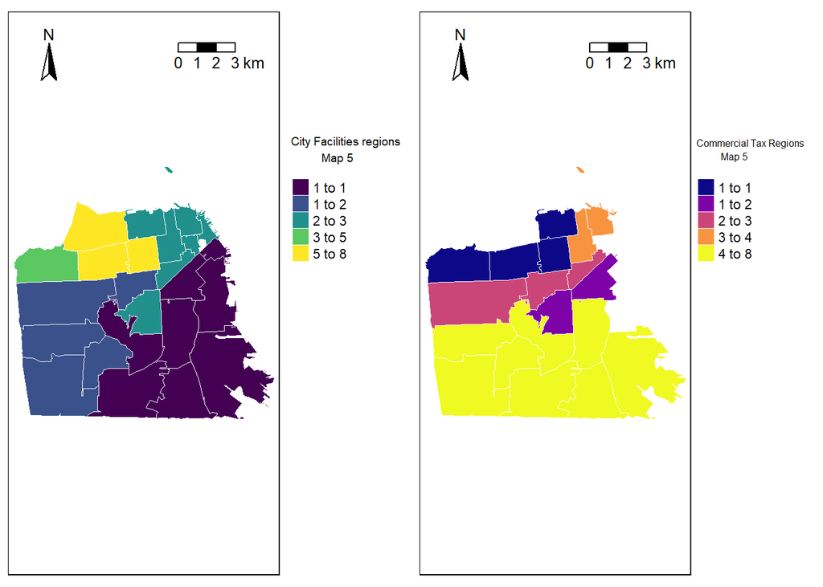

```r
tmap_arrange(map_cluster, map_cluster_2)
```

Map 5 is showing regionalized areas of San Francisco by city facilities and commercial vacancy taxpayers’ location. The geographical insight from regionalisation is economic activity indicating areas with commercial significance and analysis of land usage. The land usage gives a short understanding of how city parts are utilized by showing where the most recreational, commercial and residential places are located. In summary, the regionalization of cities with selected criteria is useful for infrastructure planning, especially for planning recreational areas. Moreover, with the help of identified areas, zoning regulations informing commercial active zones is one of the useful applications for urban policy as infrastructure planning for facilities.

## References:

1. CN, P. (2022) The rbind() function in R - binding rows Made Easy, DigitalOcean. Available at: https://www.digitalocean.com/community/tutorials/rbind-function-r
2. *Geographic Coordinate Systems 101: A Primer for Software Generalists* (no date) *8th Light*. Available at: https://8thlight.com/insights/geographic-coordinate-systems-101#:~:text=Knowingly%2C%20or%20unknowingly%2C%20all%20web,the%20surface%20of%20the%20earth. (Accessed: 27 December 2023).
3. Bivariate Choropleth Maps: A how-to guide (2015) Joshua Stevens - Visual Communicator. Available at: https://www.joshuastevens.net/cartography/make-a-bivariate-choropleth-map/
4. Christopher Prener, Ph.D. (2022) Bivarite Mapping with ggplot2, Bivarite mapping with GGPLOT2. Available at: https://cran.r-project.org/web/packages/biscale/vignettes/biscale.html
5. Smith, D. and Longley, G. (2021) ‘Geospatial analysis’, Encyclopedic Dictionary of Archaeology, pp. 525–525. doi:10.1007/978-3-030-58292-0_70116.
6. Haining, R. P. (2001) ‘Spatial Autocorrelation’, in Smelser, N. J. and Baltes, P. B. (eds) International Encyclopedia of the Social & Behavioral Sciences. Oxford: Pergamon, pp. 14763–14768. doi: 10.1016/B0-08-043076-7/02511-0.
7. Gimond, M. (2019) A basic introduction to Moran’s I analysis in R. Available at: https://mgimond.github.io/simple_moransI_example/#step_4:_computing_the_moran%E2%80%99s_i_statistic